# Data exploration

data busteRs

# What is this episode about?

Before starting to build models, and before starting the analysis of the data, one should take a closer look at such data.

Observing the data, often without any specific purpose, is called exploration.

First look at the data. Checking which variables, which ranges of variables, which relationships between the variables we have to deal with.

Exploration often begins with observing each variable individually, or in pairs, based on simple graphical or tabular summaries.

In this episode we'll show how to present the distribution of a quantitative variable and the qualitative variable with a few popular statistics.

For quantitative (numerical) variable we'll present

- mean value, median,
- Tukey's five-number summary,
- boxplot, histogram.

For qualitative (with categories) variable we'll present

- contingency table,
- sorting.

# Movie and TV Series database

In the IMDB movie database (Internet Movie Database) one can find different interesting data concerning TV series. In particular, the average user ratings issued for subsequent episodes of the series.

For example no the http://www.imdb.com/title/tt0903747/epdate?ref_=ttep_ql_4 website there are ratings for *Breaking Bad* TV series.

For the purposes of this episode we have downloaded data from the Internet, adjusted them and shared them in a dataset `serialeIMDB` in a packet `PogromcyDanych`, which was attached to this course.

The entire data set is quite large, all episodes of all series constitute over 20 thousand lines, each described by 8 columns/variables.

For the first few lines we'll take a look at the columns in order.

```r
# wczytujemy zbiór danych, jeżeli nie jest zainstalowany to należy go zainstalować
# poleceniem install.packages("PogromcyDanych")
library(PogromcyDanych)
# wielkość zbioru danych
dim(serialeIMDB)
```

```
## [1] 20122     8
```

```r
# pierwsze 6 wierszy, w kolejnych kolumnach jest nazwa serialu, nazwa odcinka,
# numer sezonu, numer odcinka, średnia ocena, liczba oddanych głosów, oraz identyfikator z bazy IMDB
head(serialeIMDB)
```

```
##   id       serial                         nazwa sezon odcinek ocena glosow    imdbId
## 1  1 Breaking Bad                         Pilot     1       1   8.7   9357 tt0903747
## 2  2 Breaking Bad           Cat's in the Bag...     1       2   8.2   6506 tt0903747
## 3  3 Breaking Bad ...And the Bag's in the River     1       3   8.3   6176 tt0903747
## 4  4 Breaking Bad                    Cancer Man     1       4   7.9   5796 tt0903747
## 5  5 Breaking Bad                   Gray Matter     1       5   7.9   5664 tt0903747
## 6  6 Breaking Bad      Crazy Handful of Nothin'     1       6   8.7   6521 tt0903747
```

# TV Series

Each line in the `serialeIMDB` data set describes ratings of one episode of one of over 200 series.

Data column called `serial` is a qualitative variable, assuming TV series names as values. Level list of the qualitative variable may be displayed with `levels()` function.

Note `serialeIMDB$serial` means reference to the `serial` column of the `serialeIMDB` data set.

```r
levels(serialeIMDB$serial)
```

```
##   [1] "Breaking Bad"                             "Cosmos: A Space-Time Odyssey"
##   [3] "Planet Earth"                             "Game of Thrones"
##   [5] "True Detective"                           "The Wire"
##   [7] "Sherlock"                                 "Cosmos"
##   [9] "The Sopranos"                             "Leyla ile Mecnun"
##  [11] "Firefly"                                  "Arrested Development"
##  [13] "I, Claudius"                              "Avatar: The Last Airbender"
##  [15] "Life"                                     "The Angry Video Game Nerd"
##  [17] "Dexter"                                   "House of Cards"
##  [19] "Batman: The Animated Series"              "Cowboy Bebop"
##  [21] "Death Note"                               "Freaks and Geeks"
##  [23] "Friends"                                  "Rome"
##  [25] "The Simpsons"                             "Twin Peaks"
##  [27] "Seinfeld"                                 "Monty Python's Flying Circus"
##  [29] "Top Gear"                                 "Oz"
```

[output cut: 84 more lines]

# Contingency table

`serialeIMDB$serial` column includes names of the series, often repetitive.

Frequency table is a useful function for exploring qualitative variables. It displays how often a specified value is present in the vector.

Frequency table can be set with a `table()` function. The result of this function can be displayed on the screen, or, as in the following example, assign to the variable.

```r
tabela <- table(serialeIMDB$serial)
# pierwsze 6 wartości z wektora
head(tabela)
```

```
##
##                 Breaking Bad Cosmos: A Space-Time Odyssey                 Planet Earth              Game of Thrones
##                           62                           13                           11                           40
##               True Detective                     The Wire
##                            8                           60
```

Contingency table for 200 series is hard to review. If we are interested in the most or the least frequent values, we can sort the contingency table to read them (`sort()` function).

After sorting by decreasing value (`decreasing = TRUE` argument) the most frequent values will be displayed at the beginning, and the least frequent at the end of the sorted vector.

```r
sort(tabela, decreasing = TRUE)
```

```
##
##          The Daily Show with Jon Stewart                       The Colbert Report
##                                     1814                                     1067
##                               Doctor Who                                One Piece
##                                      819                                      679
##                            Dragon Ball Z                             The Simpsons
##                                      589                                      564
##                        Naruto: Shippûden                                 Top Gear
##                                      397                                      276
##                              MythBusters                               South Park
##                                      258                                      257
##                                  M*A*S*H                   The Andy Griffith Show
##                                      251                                      249
##                               Family Guy                                  Friends
##                                      240                                      238
##                 Whose Line Is It Anyway?                            Stargate SG-1
##                                      214                                      213
##                             Supernatural                    How I Met Your Mother
##                                      208                                      208
##                        All in the Family            Late Night with Conan O'Brien
##                                      208                                      205
##                               The Office                              The X-Files
##                                      201                                      201
##             Mystery Science Theater 3000                                       24
##                                      197                                      195
##                           Adventure Time                                   Scrubs
##                                      182                                      182
##                              I Love Lucy                                       QI
##                                      181                                      179
##                               House M.D.           Star Trek: The Next Generation
##                                      176                                      176
##                      The Big Bang Theory                                 Seinfeld
##                                      173                                      172
##                        Dragon Ball Z Kai                             Regular Show
##                                      168                                      167
##                            Twilight Zone                            The West Wing
##                                      156                                      155
##                              Dragon Ball                               Dragonball
##                                      153                                      151
##                The Angry Video Game Nerd                                   Castle
```

[output cut: 144 more lines]

```
##                                       12                                       12
##                                   Utopia                             Planet Earth
##                                       12                                       11
##                                 Sherlock                        Hellsing Ultimate
##                                       11                                       10
##                           True Detective                      Summer Heights High
##                                        8                                        8
##                             Black Mirror                          The Black Adder
##                                        7                                        7
##                    Blackadder Goes Forth                           Black-Adder II
##                                        6                                        6
##                    Black Adder the Third               Garth Marenghi's Darkplace
##                                        6                                        6
##                            Police Squad!                                     FLCL
##                                        6                                        6
```

# Breaking Bad

The entire TV series data set constitutes of over 20 thousand lines. Operating a data set that large, concerning all the TV series, is hard because we cannot possibly see all 20 thousand lines at once.

Therefore, for the further examples we will choose one series from the data set, which we will look at more closely. Herein it will be *Breaking Bad*, but it's worth it to experiment with different series.

```r
# funkcją filter() wybieramy tylko wiersze dla serialu Breaking Bad
BreakingBad <- filter(serialeIMDB, serial == "Breaking Bad")
# o ilu odcinkach dostępna jest informacja dla tego serialu?
dim(BreakingBad)
```

[output not shown]

```r
# a jak wyglądają dane dla serialu Star Trek: The Next Generation
filter(serialeIMDB, serial == "Star Trek: The Next Generation")
```

[output not shown]

[output cut: 162 more lines]

# What happens with the episode ratings?

What can we do with data of one TV series?

The pattern of rating specific series is surely interesting. This information is available in the `ocena` column and we can access it by referring to this column with the `$` operator.

However, each episode was rated differently, one more favorably, the other less favorably. Let's compare three methods of presenting ratings information. Does any of these numbers presentation methods allow us to notice something interesting?

The episodes are sorted by their premiere dates.

1. Method one: numbers vector

```r
BreakingBad$ocena
```

```
##  [1]  8.7  8.2  8.3  7.9  7.9  8.7  8.4  8.1  8.7  7.9  7.8  7.8  8.3  8.2  8.5  8.5  8.0  8.2  8.6  8.6  8.0  8.1  7.8
## [24]  7.7  8.0  8.6  9.0  8.1  7.8  7.4  7.9  8.9  9.1  8.6  7.8  7.6  8.1  8.1  7.8  8.2  8.6  8.2  9.1  9.2  8.8  9.7
## [47]  8.8  8.4  8.4  8.3  9.3  8.5  9.0  9.2  9.0  8.7  9.2  8.6  9.6 10.0  9.4  9.9
```

# What happens with the episode ratings?

2. Method two: bar plot, height of the bar corresponds with the rating.

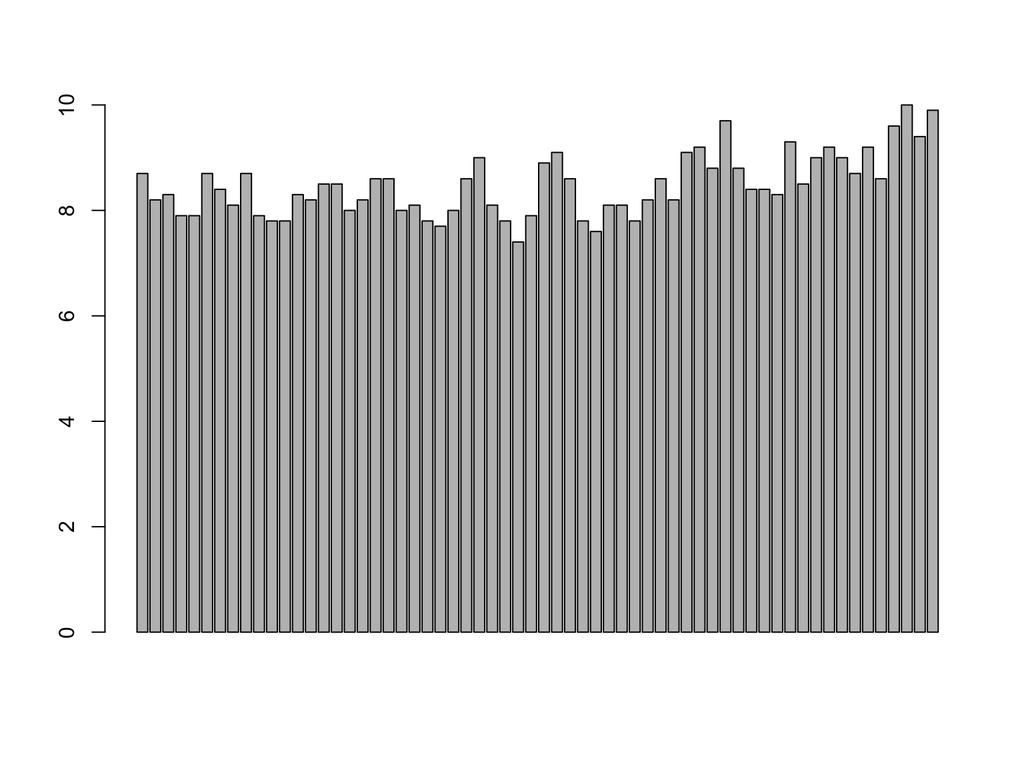

```r
barplot(BreakingBad$ocena)
```

# What happens with the episode ratings?

3. Method three: scatter plot, position of the dot corresponds with the episode's rating.

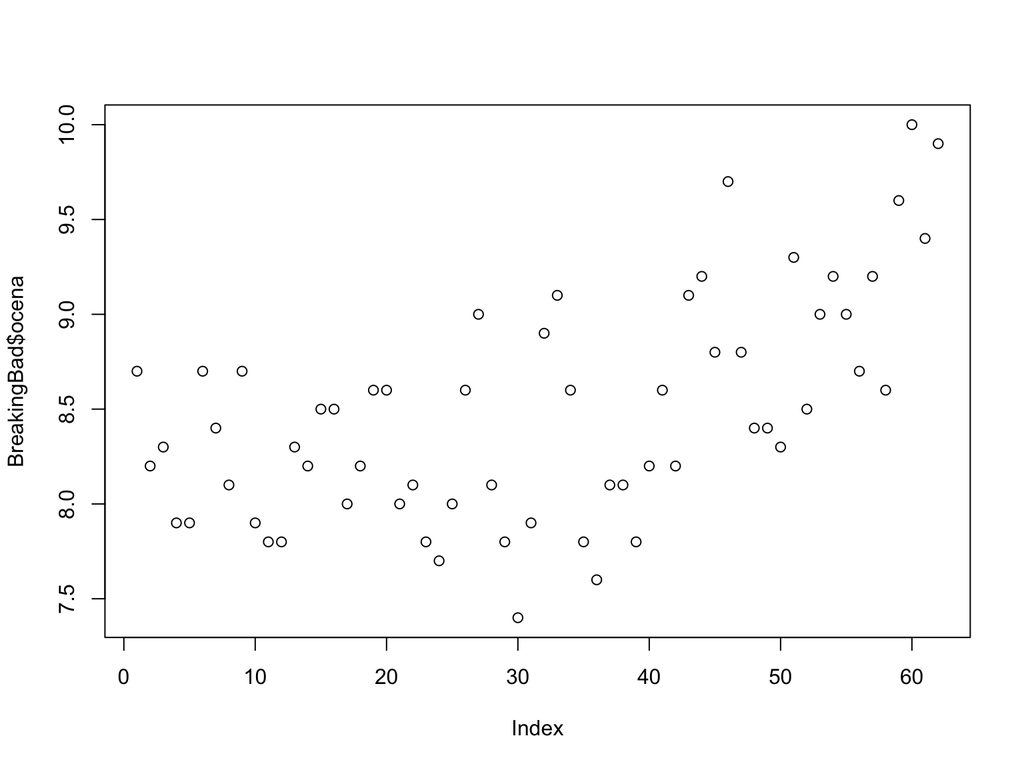

```r
plot(BreakingBad$ocena)
```

# Sorting

Often, the most interesting observations are the extreme ones.

What is the easiest way to check which episodes gather extreme ratings?

The easiest way is to sort episodes by rating and display the sorted data set. The lowest rated episode will appear at the beginning, and the highest rated episodes will appear at the end.

```r
arrange(BreakingBad, ocena)
```

```
##    id       serial                         nazwa sezon odcinek ocena glosow    imdbId
## 1  30 Breaking Bad                           Fly     3      10   7.4   7737 tt0903747
## 2  36 Breaking Bad                    Open House     4       3   7.6   4762 tt0903747
## 3  24 Breaking Bad                   Green Light     3       4   7.7   4561 tt0903747
## 4  11 Breaking Bad                          Down     2       4   7.8   4932 tt0903747
## 5  12 Breaking Bad                      Breakage     2       5   7.8   4855 tt0903747
## 6  23 Breaking Bad                        I.F.T.     3       3   7.8   4613 tt0903747
## 7  29 Breaking Bad                    Kafkaesque     3       9   7.8   4591 tt0903747
## 8  35 Breaking Bad             Thirty-Eight Snub     4       2   7.8   4853 tt0903747
## 9  39 Breaking Bad                      Cornered     4       6   7.8   4716 tt0903747
## 10  4 Breaking Bad                    Cancer Man     1       4   7.9   5796 tt0903747
## 11  5 Breaking Bad                   Gray Matter     1       5   7.9   5664 tt0903747
## 12 10 Breaking Bad             Bit by a Dead Bee     2       3   7.9   5025 tt0903747
## 13 31 Breaking Bad                       Abiquiu     3      11   7.9   4623 tt0903747
## 14 17 Breaking Bad                          Over     2      10   8.0   4901 tt0903747
```

[output cut: 48 more lines]

# How was this series rated?

For Breaking Bad TV series we have information about 62 episode available.

Each one has a specific average rating, but we sometimes want to consider all of the episodes as entirety of the show. Is the entire series good or not?

How to summarize the ratings of 62 episodes?

Two of the most popular methods are mean value and median (i.e. the middle value). They may be easily acquired by `mean()` and `median()` functions.

```r
mean(BreakingBad$ocena)
```

```
## [1] 8.480645
```

```r
median(BreakingBad$ocena)
```

```
## [1] 8.4
```

Median is a value, which is in the middle after sorting (or, if there is even amount of values, it is a mean value of two middle values).♣

More information than only the mean value are included in Tukey's five-number summary. They can be acquired (alongside arithmetic mean value) with `summary()` function. Those five numbers display:

- `Min` rating of the worst episode,
- `Max` rating of the best episode,
- `Median` rating of the middle episode (if there is odd number of episodes) or mean value of two middle episodes (if there is even number of episodes),
- `1st Qu.` and `3rd Qu.`, namely quartile ratings (the middle observation from the minimum to the median and from the median to the maximum).

Tukey's five-numbers summary divides values into four equinumerous groups.

```r
summary(BreakingBad$ocena)
```

```
##    Min. 1st Qu.  Median    Mean 3rd Qu.    Max.
##   7.400   8.025   8.400   8.481   8.800  10.000
```

# Five numbers - boxplot

Tukey's five-number summary may be displayed graphically. Boxplot is used to provide such a presentation.

In this plot there are five horizontal lines and each corresponds to one quartile.

The same amount of values is located between adjacent horizontal lines. If one of these segments is longer than the others, it means that the values in it are rarer than in the others.

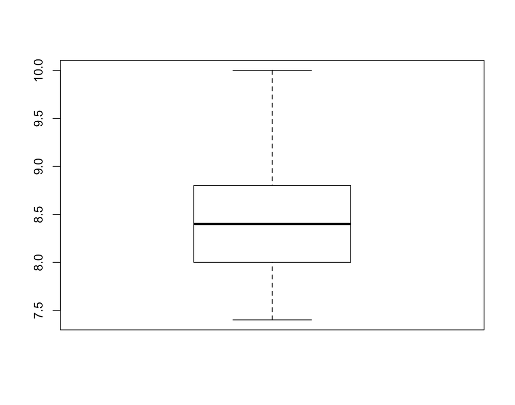

```r
boxplot(BreakingBad$ocena )
```

# Five numbers - boxplot

An advantage of the boxplot is the fact that it allows for easier and better comparison of observation groups.

Let's observe how the episodes rating differentiate between seasons.

How to do this in R program? In `boxplot()` function we will use `~` formula symbol to specify that we want to present the ratings broken down by seasons. The left side of the symbol specifies variable that we want to summarize, and the right side defines the groups we want to compare.

What can we read from such a representation of data? A large number of things. Let's try to deal with this issue individually for a moment. On the plot below we'll find three interesting observations.

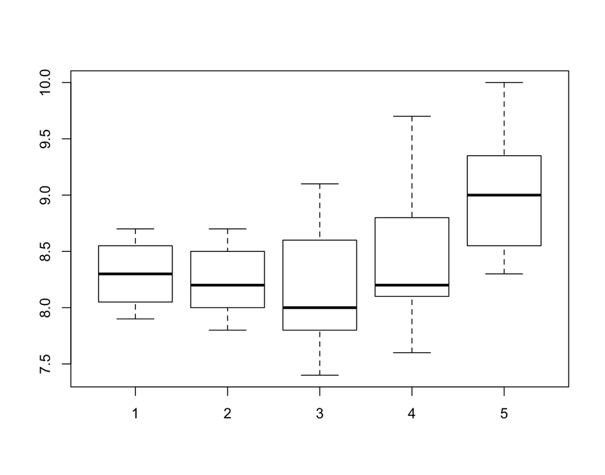

```r
BreakingBad$sezon <- droplevels(BreakingBad$sezon)
boxplot(BreakingBad$ocena ~ BreakingBad$sezon)
```

# Five numbers - boxplot

What interesting observations were made? For me the most interesting observations are:

1. Season 5 has the best ratings. Its median is above the whole box for seasons 1 and 2, which means that more than half of the episodes of season 5 were rated higher than the best episode of the first two seasons.
2. The weakest ratings are in season 3. It contains the worst-rated episode. Its median is also the lowest.
3. The greatest variability is observed for season 4. It contains both a very poor episode (for this series) and a very good episode.

[figure not shown]

# Histogram

How else can display pattern of ratings?

Histogram is an interesting alternative. Data presentation rule is as follows:

We divide the range of values by a certain number (below it is `breaks = 10`) of intervals of equal length. Next we check how many values fall into each interval. On the plot we denote the number of these observations with the bar height.

The taller the bars, the bigger the density of observations in a given interval.

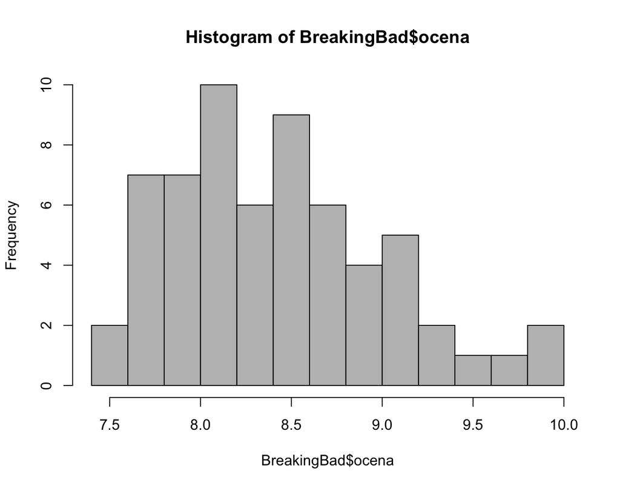

```r
hist(BreakingBad$ocena, breaks = 10, col="grey")
```

# What can we learn from histogram that we cannot learn from other measures?

Histogram is a more complicated plot than the boxplot.

Does that complication provide any useful information?

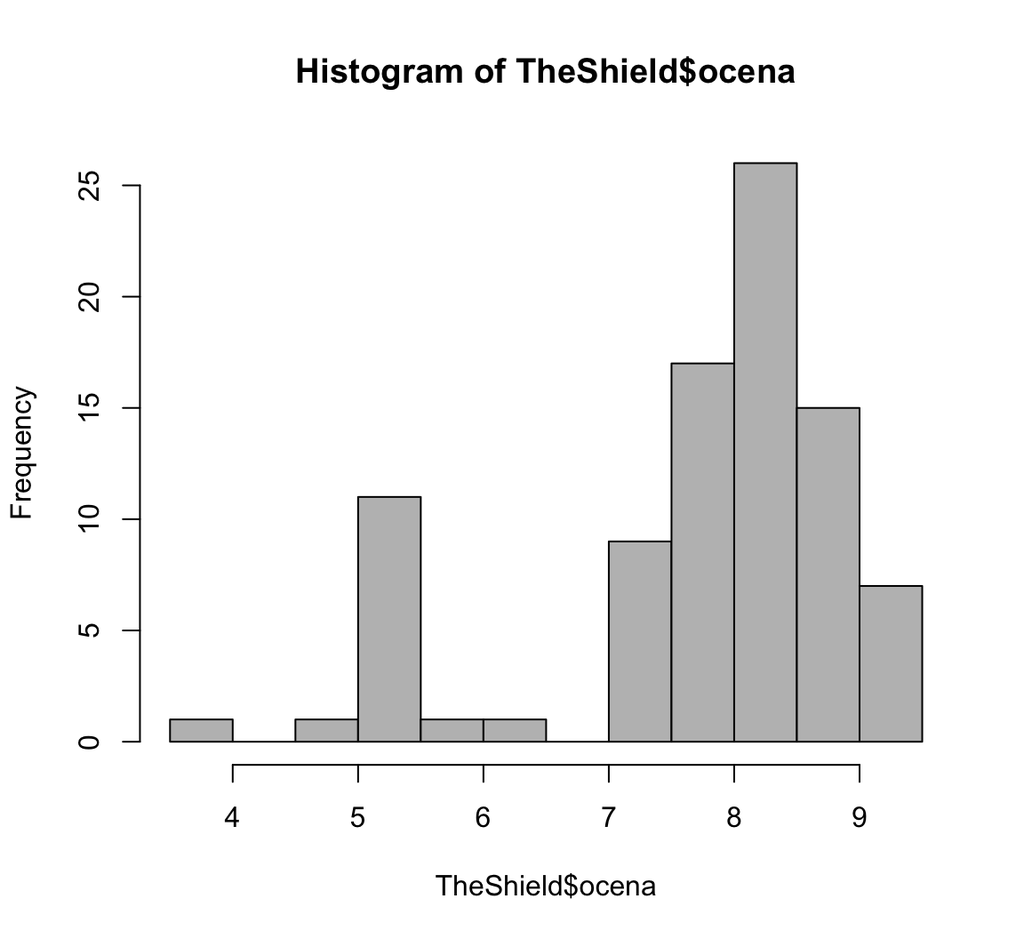

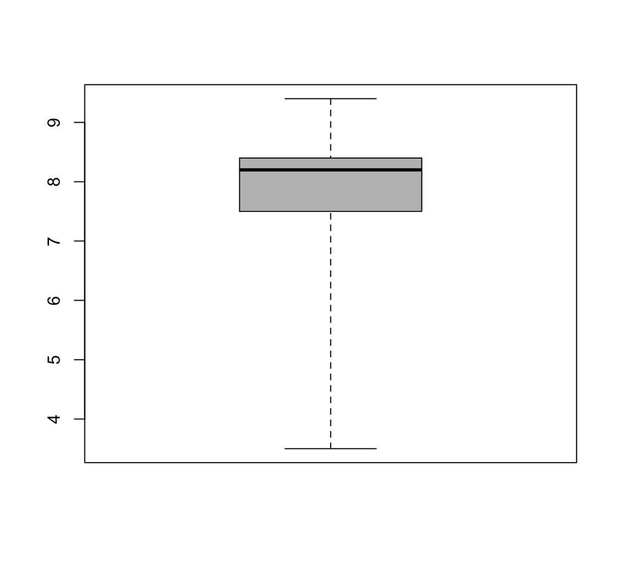

```r
TheShield <- filter(serialeIMDB, serial == "The Shield")
hist(TheShield$ocena, 10, col="grey")
boxplot(TheShield$ocena, col="grey", range = 10)
```

# Summary of R instructions

In this episode we have discussed functions which are used for numerical and graphic exploration of quantitative data.

```r
# pakiet z danymi
library(PogromcyDanych)

# wielkość danych i kilka pierwszych wierszy
dim(serialeIMDB)
head(serialeIMDB)

# wartości zmiennych jakościowych
levels(serialeIMDB$serial)

# jak wyznaczyć tabelę liczebności i ją posortować
tabela <- table(serialeIMDB$serial)
sort(tabela, decreasing = TRUE)

# wybieramy tylko dane dotyczące serialu Breaking Bad
BreakingBad <- filter(serialeIMDB, serial == "Breaking Bad")
# o ilu odcinkach dostępna jest informacja dla tego serialu?
dim(BreakingBad)

# różne sposoby oglądania informacji o odcinkach
BreakingBad$ocena
barplot(BreakingBad$ocena)
plot(BreakingBad$ocena)
```

# Summary of R instructions

In this episode we have discussed functions which are used for numerical and graphic exploration of quantitative data.

```r
# sortowanie danych
arrange(BreakingBad, ocena)

# podsumowanie danych o ocenach
summary(BreakingBad$ocena)

# wykres pudełkowy
boxplot(BreakingBad$ocena )

# wykres pudełkowy dla grup
BreakingBad$sezon <- droplevels(BreakingBad$sezon)
boxplot(BreakingBad$ocena ~ BreakingBad$sezon)

# histogram a więc pełna informacja o rozkładzie
hist(BreakingBad$ocena, 10, col="grey")

# kiedy histogram zdradza dodatkowe informacje
TheShield <- filter(serialeIMDB, serial == "The Shield")
hist(TheShield$ocena, 10, col="grey")
boxplot(TheShield$ocena, col="grey", range = 10)
```

# Tasks

- Choose *Friday Night Lights* TV series and review how its popularity looks like. Is it more popular than *Breaking Bad*?
- Review how the popularity of this series was changing in time. Have you noticed anything interesting?
- Instead of presenting information about episode ratings, present information about the number of votes cast (popularity) for episodes. Are the same statistics equally suitable for presentation information about ratings and the votes cast?